# lab07

Hye Soo Choi

## Writing Functions

In this lab, we’ll focus on writing functions, with fewer examples and more time writing code.

### Basic Functions, with Control Flow Structures

Often you will find that it is easier to begin writing code for a specific task, with specific variables, before generalizing the code into a function. Last lab, we saw the following code, which divides a positive integer by 2 until it becomes odd.

```r
x <- 898128000 # Change this value!
while (x %% 2 == 0) {
  print(x)
  x <- x / 2
}
```

```
## [1] 898128000
## [1] 449064000
## [1] 224532000
## [1] 112266000
## [1] 56133000
## [1] 28066500
## [1] 14033250
```

```r
print(x)
```

```
## [1] 7016625
```

Your turn! Now generalize the above code to create a function which performs the same operation. (You should change very little.)

```r
reduce <- function(x) {
  repeat{
    if(x %% 2 == 0){
      print(x)
      x<-x/2
    }
    else{
      return(x)
      break
    }
  }
}

reduce(898128000)
```

```
## [1] 898128000
## [1] 449064000
## [1] 224532000
## [1] 112266000
## [1] 56133000
## [1] 28066500
## [1] 14033250
```

```
## [1] 7016625
```

How about something a little bit more complicated? Write a function `f` which, given a positive integer `n`, returns `n / 2` if `n` was even or `3 * n + 1` if `n` was odd.

```r
f <- function(n) {
  if(n %% 2 == 0)
    return(n/2)
  else {
    return(3 * n + 1)
  }
  # Fi
}

f(6)
```

```
## [1] 3
```

```r
f(19)
```

```
## [1] 58
```

```r
f(27)
```

```
## [1] 82
```

Now create function `g` which applies `f()` to a positive integer `n` until it becomes 1, and returns the number of iterations until this occurs.

```r
g <- function(n) {
  k <- 1
  while(n != 1){
    n <- f(n)
    k <- k+1
  }
  return(k)
  # Fill in.
}

g(6)
```

```
## [1] 9
```

```r
g(19)
```

```
## [1] 21
```

```r
g(27)
```

```
## [1] 112
```

If you didn’t earlier, try also writing the same function, but now create `f()` as a nested function.

```r
h <- function(n) {
  f <- function(m) {
    if(m %% 2 == 0){
      m <- m/2
    }
    else{
      m <- 3* m + 1
    }
    return(m)
  }
  k <- 1
  while(n != 1){
    n <- f(n)
    k <- k + 1
  }
  return(k)# Fill in.
}

h(6)
```

```
## [1] 9
```

```r
h(19)
```

```
## [1] 21
```

```r
h(27)
```

```
## [1] 112
```

### Default Arguments

As you probably know by now, many functions come with default arguments, which can be left unspecified without affecting the execution of the function.

The following function attempts to compute the length of the hypotenuse of a right triangle, but will accept one or two leg lengths.

```r
pythagoras <- function(a, b = a) {
  return(sqrt(a^2 + b^2))
}

pythagoras(3, 4)
```

```
## [1] 5
```

```r
pythagoras(5)
```

```
## [1] 7.071068
```

**Your turn!** Write a function which adds together the elements of a vector raised to a certain power. Use a loop instead of vectorized operations. Include two arguments: `vec` and `pow`. Give `pow` a default value of 2.

```r
# Remove eval = FALSE or set eval = TRUE when you have completed this function.
powersum <- function(vec, pow = 2) { # Fill in arguments.

  return(sum(vec^pow))
  # Fill in.
}

powersum(1:5) # Should return 55.
```

```
## [1] 55
```

```r
powersum(1:5, 4) # Should return 979.
```

```
## [1] 979
```

### Ellipsis (…)

Finally, in addition to normal and default arguments, the `...` argument allows a function to take any number of arguments.

The following function simply counts the number of arguments given.

```r
countargs <- function(...) {
  print(paste("This function received", length(list(...)), "arguments."))
}

countargs(0)
```

```
## [1] "This function received 1 arguments."
```

```r
countargs(1L, 5, 3 + 5i, TRUE, "yosemite")
```

```
## [1] "This function received 5 arguments."
```

```r
countargs(c(1, 2, 3, 4, 5), factor(c("one", "two", "three")))
```

```
## [1] "This function received 2 arguments."
```

More commonly, however, the `...` is simply passed as optional arguments to another function.

**Your turn!** Write a function which produces a histogram of a random process. The first argument should be `n`, the number of observations. The second argument should be one of the following: `"Uniform", "Binomial", "Poisson"`. These should correspond, respectively, to: `runif(n), rbinom(n, 100, 0.5), rpois(n, 1)`. Finally, include the `...` argument to be passed into the histogram function.

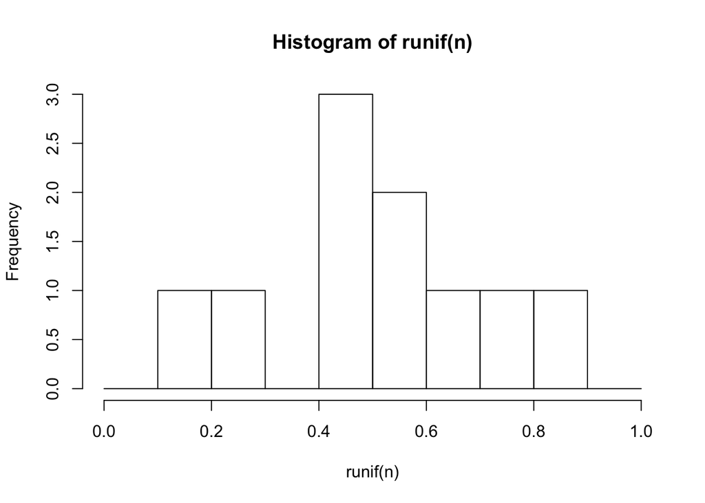

```r
# Remove eval = FALSE or set eval = TRUE when you have completed this function.
randhist <- function(n, dist, ...) { # Fill in arguments.
  if(dist == 'Uniform'){
    hist(runif(n),...)
  }
  else if(dist == 'Binomial'){
    hist(rbinom(n, 100, 0.5), ...)
  }
  else if(dist == 'Poisson'){
    hist(rpois(n,1), ...)
  }
  else{
    stop('one of Uniform, Binomial, or Poisson should be  given')
  }
  # Fill in.
}

randhist(10, "Uniform", breaks = seq(0, 1, 0.1))
```

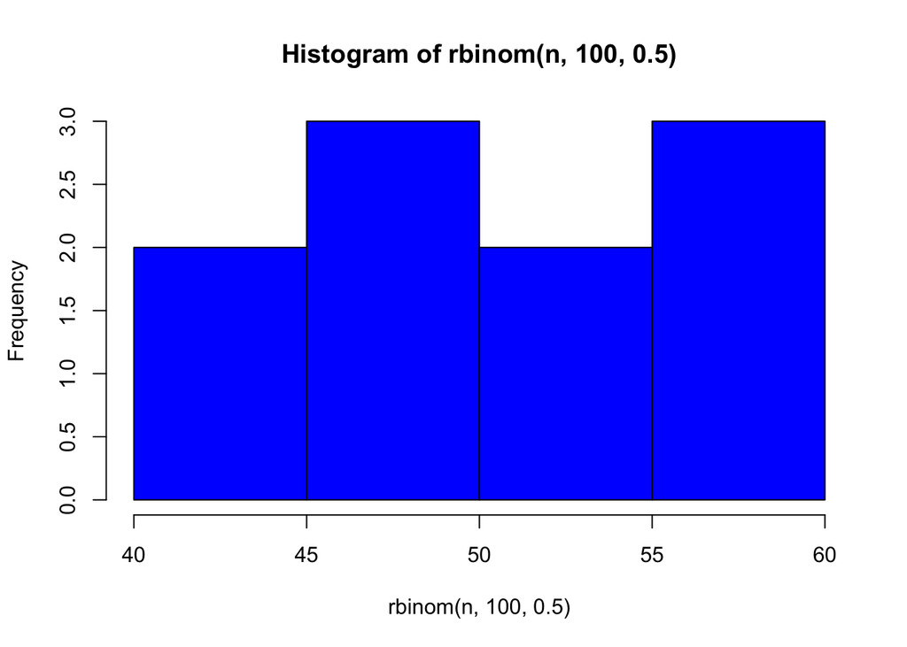

```r
randhist(10, "Binomial", col = "blue")
```

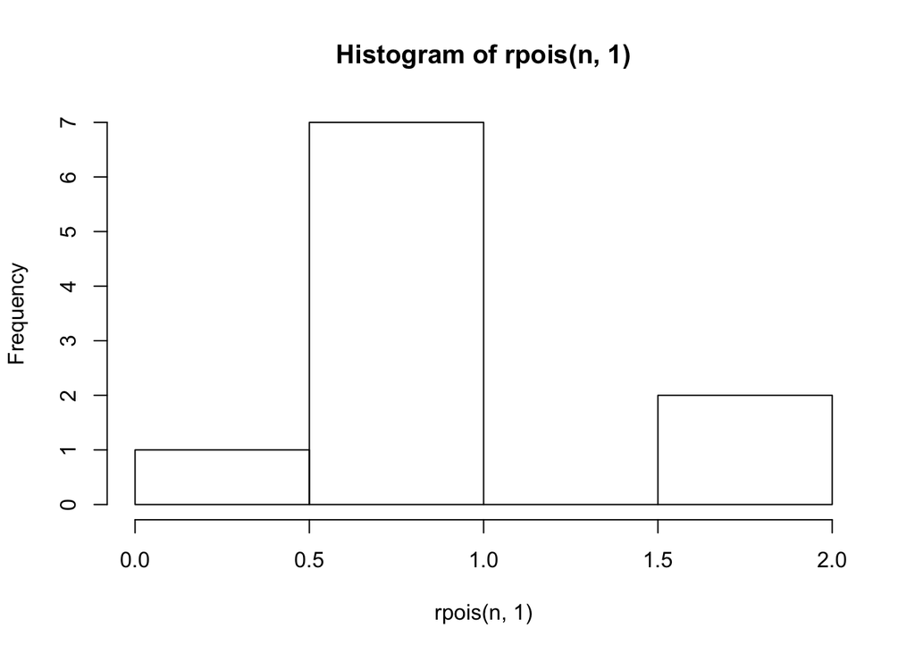

```r
randhist(10, "Poisson")
```